# 🦇 Convolutional Neural Networks: The Main Components

Convolution, ReLU, pooling, and a dense layer, and one photo traced through all of them

Son Nguyen

## The Big Picture

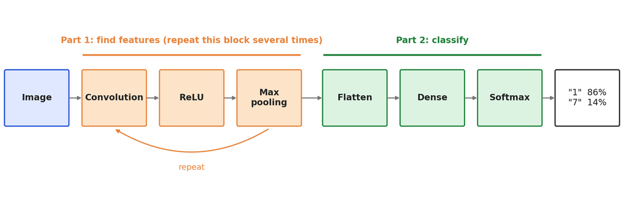

- **Convolution** finds patterns · **ReLU** keeps the matches · **Pooling** shrinks the maps
- **Flatten + Dense + Softmax**: the familiar network, giving class probabilities

Today: each component, then **one real image** through every layer **by hand**.

# Part 1. The Convolutional Layer

## An Image Is a Grid of Numbers

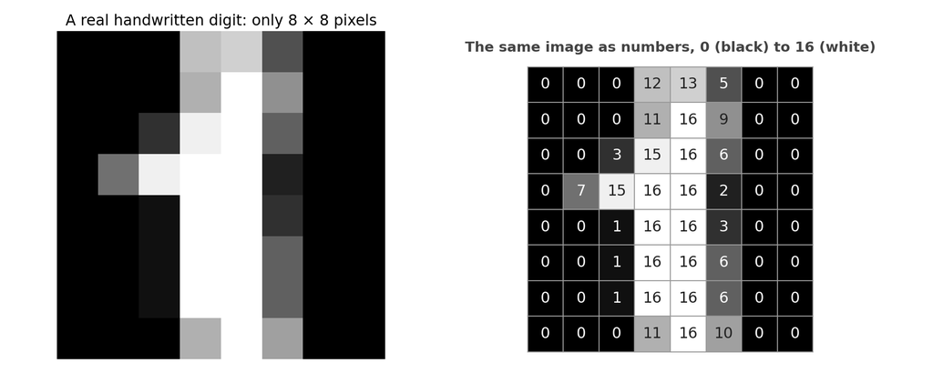

- A gray image is **one** matrix of brightness values (a color image is three).
- This digit comes from a real dataset of handwritten digits. It really is only 8 × 8: **nothing was shrunk**.
- Small enough to push through a CNN **by hand**. Notice the bright stroke: it has a **vertical edge** on each side.

## The Convolutional Layer: A Small Filter That Slides

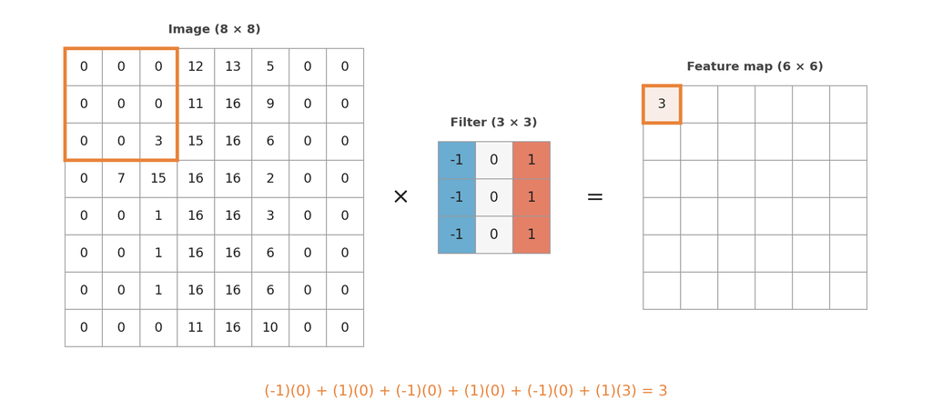

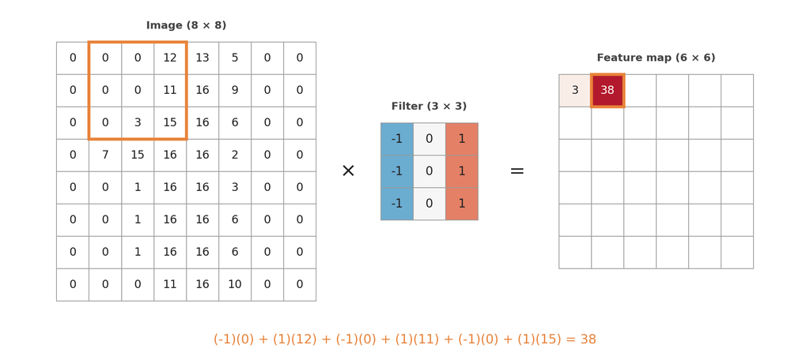

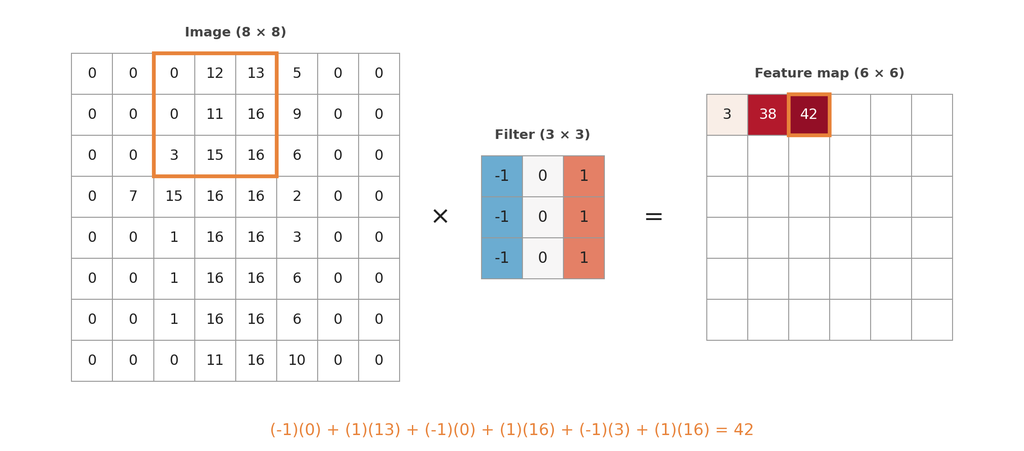

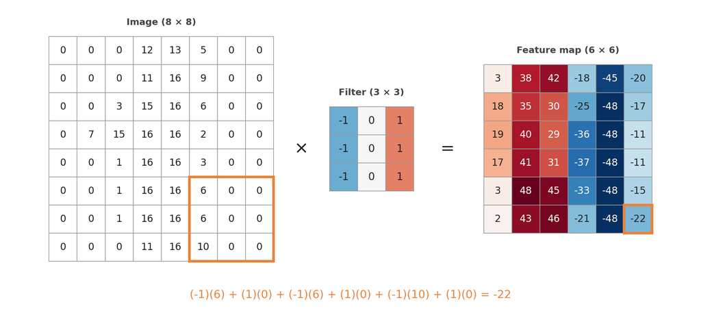

- Put the 3 × 3 filter on a 3 × 3 window, **multiply matching entries and add**: one inner product, one output number.
- Slide one step and repeat. The filter is **the same** at every position (weight sharing).
- An 8 × 8 image and a 3 × 3 filter give a 6 × 6 **feature map**: $8 - 3 + 1 = 6$.

## What a Filter Finds

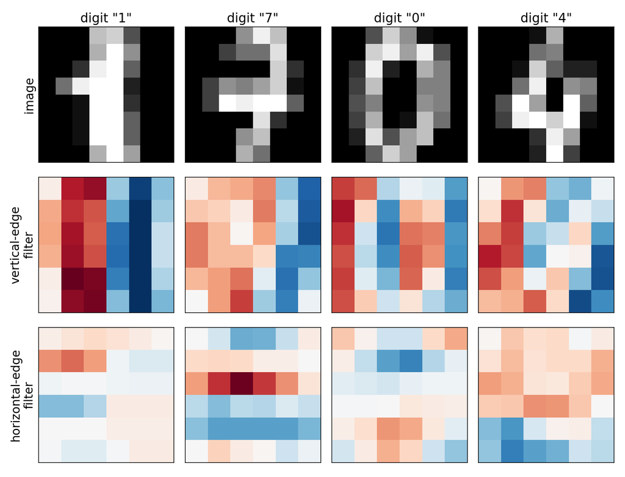

- Each output number measures **how well that window matches the filter’s pattern**. **Red**: strong match (dark → bright). **Blue**: the opposite. **White**: nothing there.
- The “1” lights up the **vertical-edge** filter; the bars of the “7” light up the **horizontal-edge** filter.
- A layer uses **many filters** and makes one feature map per filter.

Nobody chooses the filter values. They are **weights**, learned in training like any other weights.

# Part 2. ReLU

## ReLU: Keep the Matches, Drop the Rest

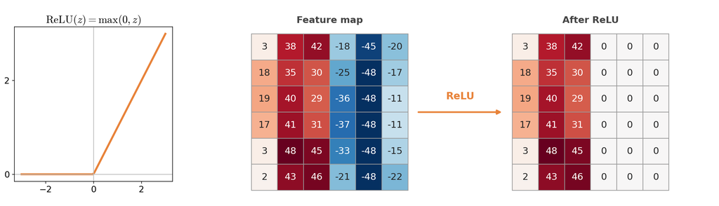

- ReLU is applied to **every number** in every feature map, one at a time. It has **no parameters**.
- Positive = “pattern found here”: **kept**. Negative = “pattern not here”: **set to 0**.
- Without it, stacked conv layers would collapse into one big linear filter. ReLU makes depth useful, and its slope of 1 keeps gradients from vanishing.

## ReLU on Four Digits

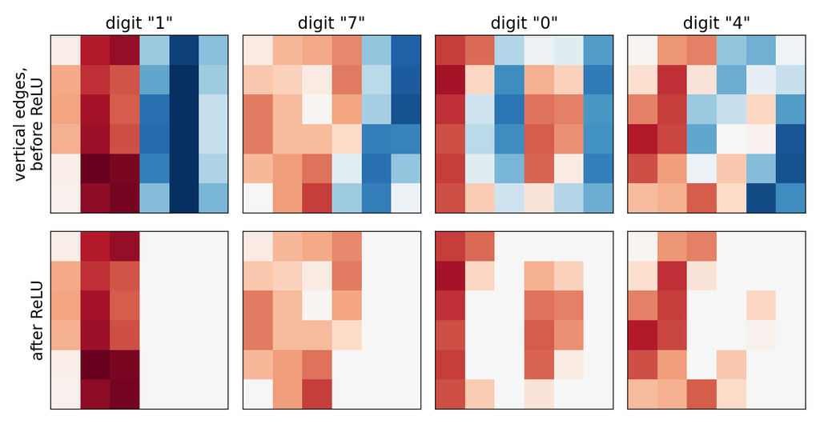

- Vertical-edge maps of the four digits: ReLU keeps the red (dark → bright) edges and turns all the blue to 0.

# Part 3. Pooling

## Max Pooling: Shrink the Map, Keep the Strongest Signal

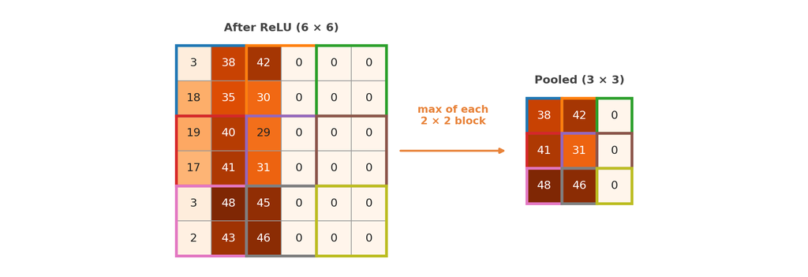

- Split each map into 2 × 2 blocks and keep the **largest** number. Height and width are cut in half.
- **Why**: fewer numbers for later layers; a feature that moves a pixel or two gives (almost) the same result; and the next filters see a **larger area** of the original image.
- **No parameters**, and it works on each feature map separately (the number of maps stays the same).

## Max Pooling on Four Digits

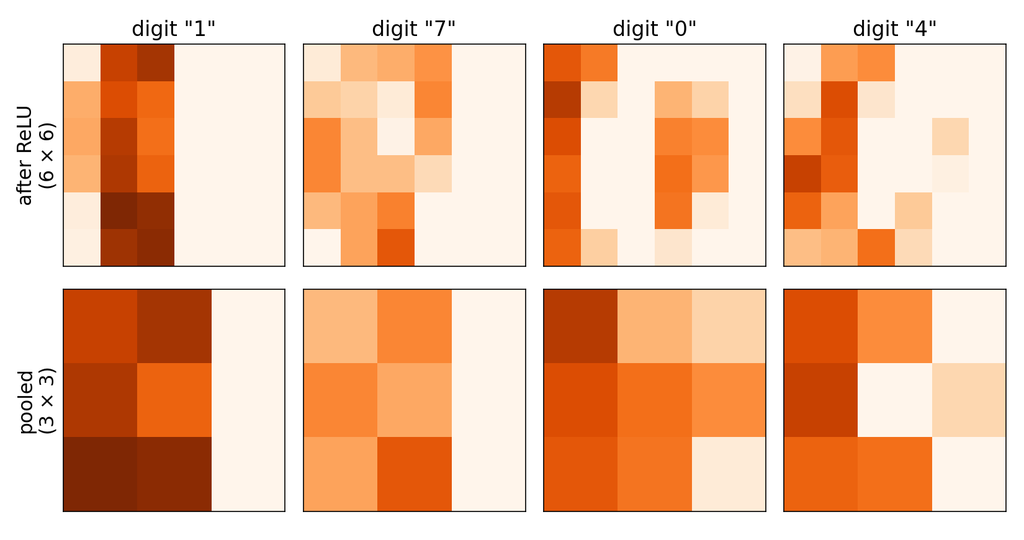

- Each 6 × 6 map becomes 3 × 3: a quarter of the numbers, but each digit’s strong edges are still there.

## Stacking the Block: Smaller Maps, More of Them

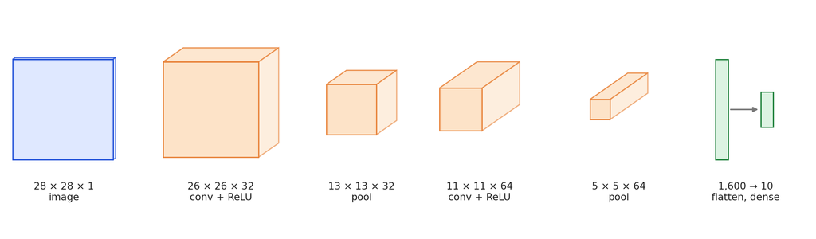

- Each conv + ReLU + pool block makes the maps **smaller** (pooling) but **more numerous** (more filters).
- Layer 1 filters see 3 × 3 pixels: edges. Later filters read earlier maps, so they see **larger areas** and find **combinations**: corners, textures, petals, eyes, wheels.

Early layers: simple, local patterns. Deep layers: complex patterns covering much of the image.

# Part 4. Flatten, Dense, Softmax

## From Feature Maps to Class Probabilities

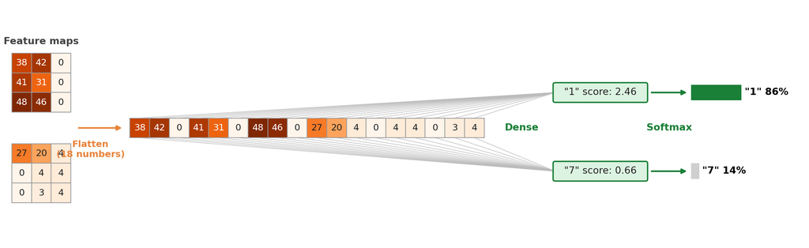

- **Flatten**: line up all the numbers from all the maps into one long list.
- **Dense layer**: each class gets a **score**, a weighted sum of every number in the list (the weights are learned).
- **Softmax**: turns the scores into **probabilities** that add up to 100%. The biggest one is the prediction.

This is the neural network we already know. The only difference: it reads the **features the filters found**, not raw pixels.

# Part 5. One Image Through the Network, by Hand

## The Network and the Image

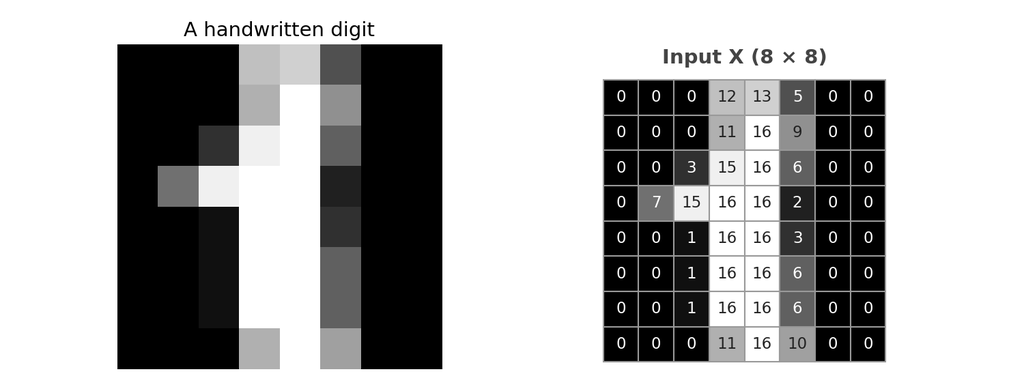

| Step | Layer | Output shape | Parameters |
| --- | --- | --- | --- |
| 1 | Convolution: 2 filters, 3 × 3 (vertical edge, horizontal edge), bias 0 | 6 × 6 × 2 | 20 |
| 2 | ReLU | 6 × 6 × 2 | 0 |
| 3 | Max pooling 2 × 2 | 3 × 3 × 2 | 0 |
| 4 | Flatten | 18 | 0 |
| 5 | Dense: 2 classes (digit “1”, digit “7”) | 2 | 38 |
| 6 | Softmax | 2 | 0 |
|  | **Total** |  | **58** |

## Step 1. Convolution: Two Filters, Two Feature Maps

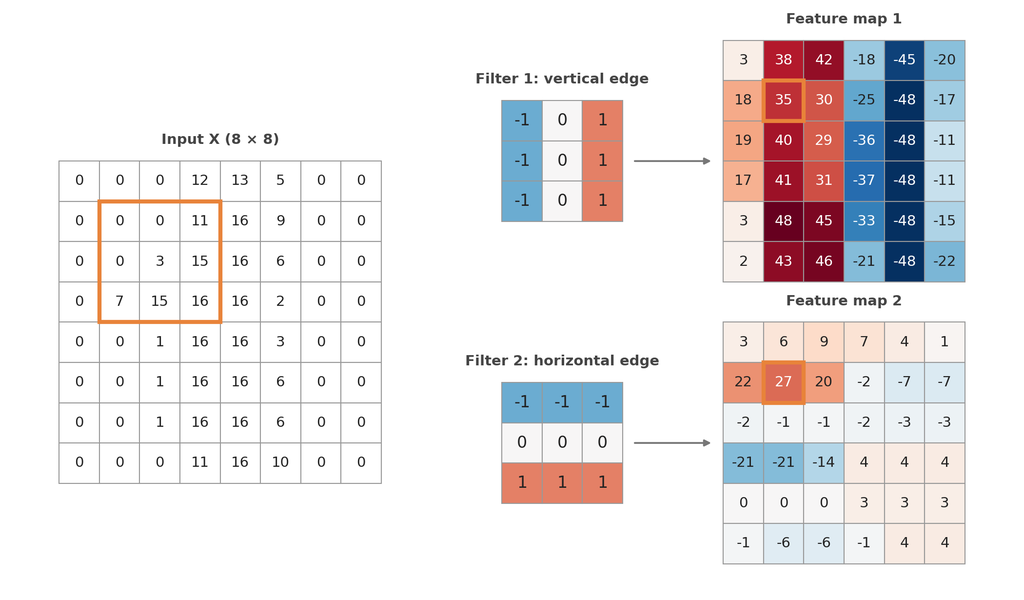

- Window in the orange box (row 2, column 2). **Filter 1** = right column minus left column: $11 + 15 + 16 − (0 + 0 + 7) = 35$.

- **Filter 2** = bottom row minus top row: $7 + 15 + 16 − (0 + 0 + 11) = 27$.

- Slide to all 36 positions. Map 1 is strong: **red** on the left side of the stroke, **blue** on the right. A “1” is mostly **vertical edges**.

## Step 2. ReLU

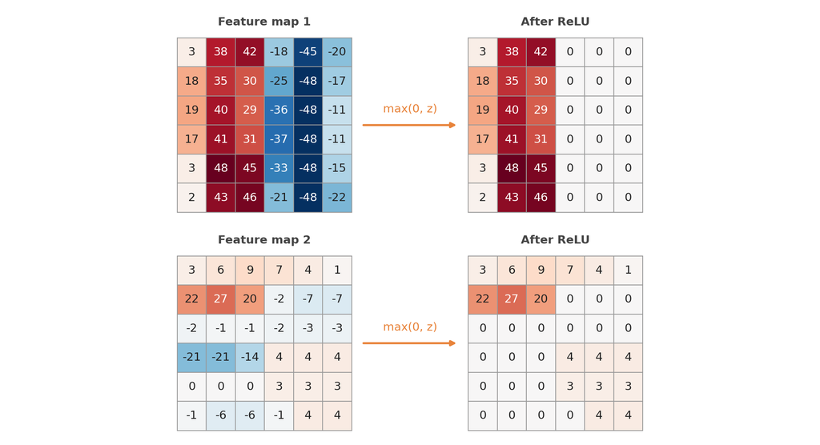

- Every negative number becomes 0; positives stay the same.

- Map 1 loses 18 numbers and map 2 loses 16: those windows showed the **opposite** of the filter’s pattern.

## Step 3. Max Pooling

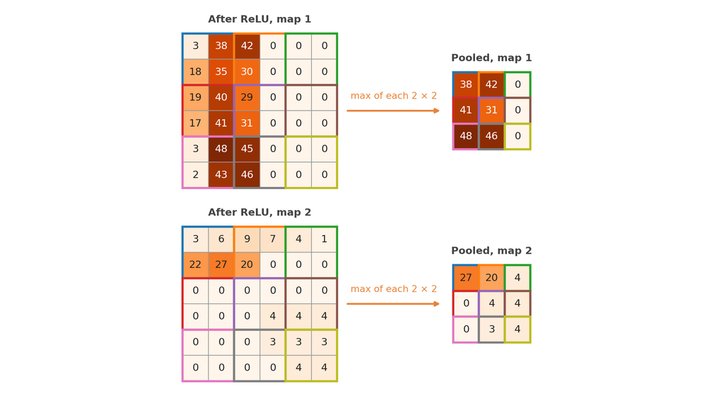

- Top-left block of map 1: $\max(3, 38, 18, 35) = 38$. Each 6 × 6 map becomes 3 × 3.

## Step 4. Flatten

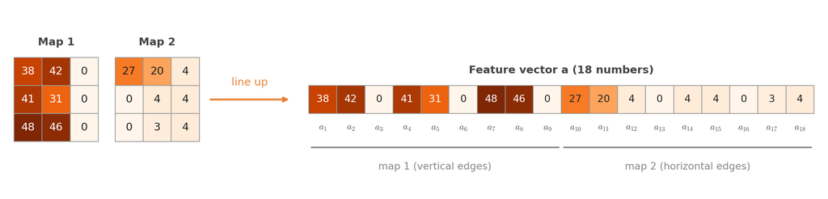

- Read each map row by row, map 1 then map 2: $\mathbf{a} = (38, 42, 0, 41, 31, 0, 48, 46, 0, 27, 20, 4, 0, 4, 4, 0, 3, 4)$.

- These 18 numbers describe the image: **how strong each edge type is, in each of 9 regions**.

## Step 5. Dense Layer: Two Scores

|  | $a_1, \dots, a_9$ (map 1: vertical edges) | $a_{10}, \dots, a_{18}$ (map 2: horizontal edges) | bias |
| --- | --- | --- | --- |
| **a** | 38, 42, 0, 41, 31, 0, 48, 46, 0 | 27, 20, 4, 0, 4, 4, 0, 3, 4 |  |
| weights, “1” | 0.01 each | 0 each | 0 |
| weights, “7” | 0 each | 0.01 each | 0 |

- $z_1 = 0.01(38 + 42 + 0 + 41 + 31 + 0 + 48 + 46 + 0) = 0.01(246) = 2.46$

- $z_7 = 0.01(27 + 20 + 4 + 0 + 4 + 4 + 0 + 3 + 4) = 0.01(66) = 0.66$

- Each score is **one inner product** of a weight row with $\mathbf{a}$ (zero weights left out).

## Step 6. Softmax: Probabilities

$$p_1 = \frac{e^{2.46}}{e^{2.46} + e^{0.66}}
= \frac{11.7}{11.7 + 1.93} = 0.858
\qquad
p_7 = \frac{1.93}{11.7 + 1.93} = 0.142$$

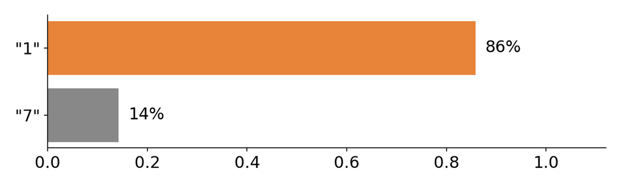

Prediction: **“1”** with probability 86%. From 64 pixels to 2 probabilities, using only inner products, $\max(0, z)$, $\max$ of blocks, and softmax.

## The Whole Trip on One Slide

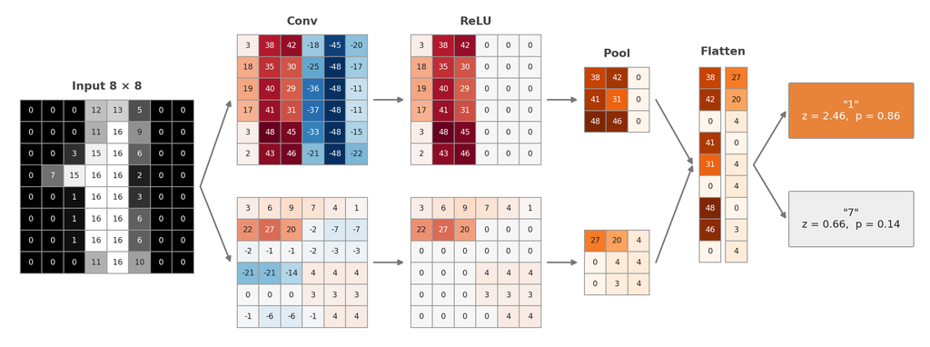

- Parameters learned in training: 2 filters (18 weights + 2 biases) and the dense layer (36 weights + 2 biases): **58** in total.

## Your Turn

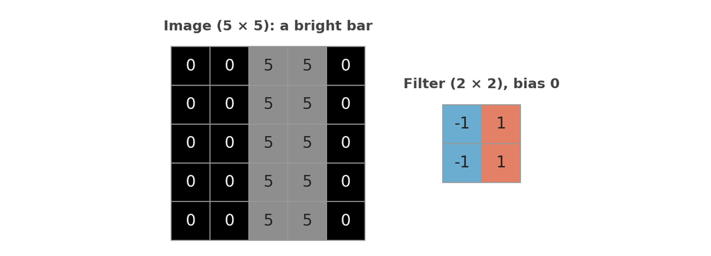

1. What is the size of the feature map? Compute it.
2. Apply ReLU. Which edge of the bar survives, and why?
3. Apply 2 × 2 max pooling.
4. How many parameters does this layer have if it uses 8 such filters on a color image?

## Your Turn: Answers

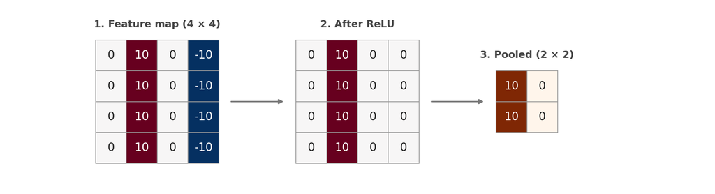

1. $5 - 2 + 1 = 4$, so 4 × 4. Each output is (right column) − (left column) of the window.

2. Only the **left** edge (dark → bright, value 10) survives; the right edge (bright → dark) is negative and becomes 0.

3. $\max$ of each 2 × 2 block, as shown.

4. Each filter is 2 × 2 × 3 with one bias: $(2 \cdot 2 \cdot 3 + 1)\cdot 8 = 104$.

# Part 6. A Real-Size CNN

## A CNN for 28 × 28 Handwritten Digits

| Layer | Output shape | Parameters |
| --- | --- | --- |
| Input | 28 × 28 × 1 | 0 |
| Conv, 32 filters 3 × 3, ReLU | 26 × 26 × 32 | 320 |
| Max pool 2 × 2 | 13 × 13 × 32 | 0 |
| Conv, 64 filters 3 × 3, ReLU | 11 × 11 × 64 | 18,496 |
| Max pool 2 × 2 | 5 × 5 × 64 | 0 |
| Flatten | 1,600 | 0 |
| Dense, 10 classes, softmax | 10 | 16,010 |
| **Total** |  | **34,826** |

- Same components as our hand calculation, just more filters and one more block.

- Second conv layer: each filter is 3 × 3 × **32**, because it reads all 32 maps of layer 1: $(3\cdot3\cdot32+1)\cdot64 =$ 18,496.

- In Keras: `Conv2D(32, 3, activation="relu")`, `MaxPooling2D(2)`, `Conv2D(64, 3, activation="relu")`, `MaxPooling2D(2)`, `Flatten()`, `Dense(10, activation="softmax")`.

## Training: Nothing New

- **Learned**: the filter weights and biases of every conv layer, and the weights and biases of the dense layer.
- **Not learned**: ReLU, pooling, and flatten have no parameters.
- **How**: exactly as before. Cross-entropy loss, gradients by backpropagation, gradient descent (Adam).
- The network discovers on its own which filters are useful: edge detectors appear in layer 1 without anyone designing them.

# Part 7. Famous CNNs

## Famous CNNs: The Same Two Parts

Every famous CNN has the shape of our Big Picture: **Part 1** (conv, ReLU, pooling, repeated) finds features; **Part 2** (flatten, dense, softmax) classifies them.

| Network | Year | Known for | Input | Classes | Parameters |
| --- | --- | --- | --- | --- | --- |
| **LeNet-5** | 1998 | reading handwritten digits on bank checks | 32 × 32 × 1 | 10 | about 60 thousand |
| **AlexNet** | 2012 | won ImageNet by a wide margin; started the deep learning boom | 227 × 227 × 3 | 1,000 | about 60 million |
| **VGG-16** | 2014 | very simple design: only 3 × 3 filters, stacked deep | 224 × 224 × 3 | 1,000 | about 138 million |
| **ResNet-50** | 2015 | “skip connections” make very deep networks trainable | 224 × 224 × 3 | 1,000 | about 26 million |

Over time Part 1 got **deeper** (more conv layers find richer features), while Part 2 stayed small or even shrank to a single dense layer.

## LeNet-5 (1998)

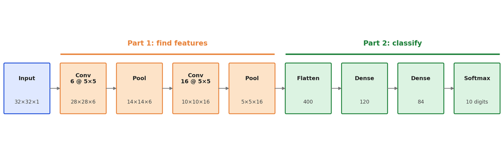

- Yann LeCun’s network for reading **handwritten digits**, used by banks to read checks in the 1990s.
- **Part 1**: two conv + pool blocks, 5 × 5 filters. **Part 2**: three dense layers, ending in 10 digit probabilities.
- Almost exactly the network from our “28 × 28 handwritten digits” slide: small, about **60 thousand** parameters.

## AlexNet (2012)

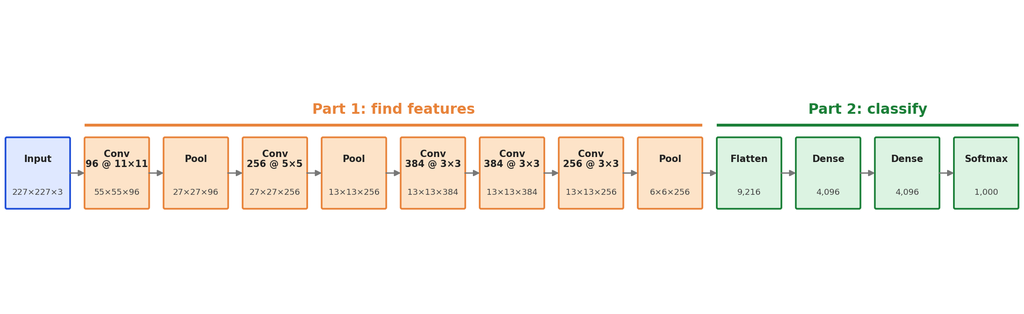

- Won the **ImageNet** challenge in 2012 (1.2 million color photos, 1,000 classes) with far fewer errors than any other method. This started the deep learning boom.
- **Part 1**: five conv layers (the first one with big 11 × 11 filters) and three pools. **Part 2**: two big dense layers + softmax.
- New tricks that are now standard: **ReLU**, training on **GPUs**, and dropout. About **60 million** parameters.

## VGG-16 (2014)

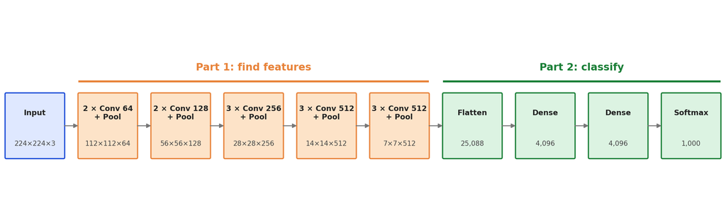

- A very regular design: **only 3 × 3 filters**, in five blocks; each block ends with a 2 × 2 max pool that halves the size.

- 13 conv layers + 3 dense layers = **16** layers with weights. About **138 million** parameters.

- Surprise: about **124 million** of them are in **Part 2** (the first dense layer alone reads 25,088 numbers).

## ResNet-50 (2015)

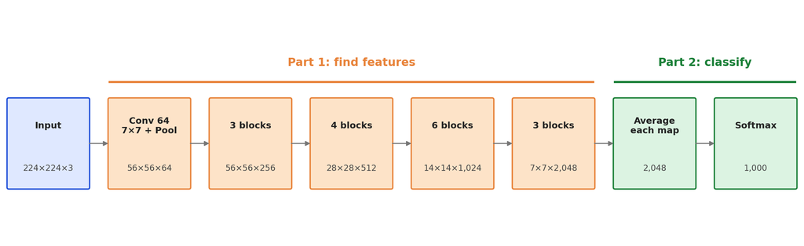

- **50 layers deep.** Each “block” is 3 conv layers plus a **skip connection** that adds the block’s input to its output, which makes very deep networks trainable.
- **Part 2 is tiny**: instead of flattening, average each of the 2,048 maps into one number, then one dense layer + softmax.
- Fewer parameters than VGG-16 (about **26 million**) but more accurate. Variants of ResNet are still widely used today.

## Summary

| Component | What it does | Parameters |
| --- | --- | --- |
| **Convolution** | a small filter slides; each output is an inner product with one window | $(f \cdot f \cdot c_{\text{in}} + 1)\cdot k$ |
| **ReLU** | $\max(0, z)$: keep where the pattern was found | 0 |
| **Max pooling** | keep the largest value in each 2 × 2 block; halves the size | 0 |
| **Flatten** | line up all maps into one vector | 0 |
| **Dense** | $W\mathbf{a} + \mathbf{b}$: one inner product per class | $(m + 1)\cdot K$ |
| **Softmax** | scores → probabilities that add to 1 | 0 |

Convolution blocks **find features**; the dense layer **classifies** them. Everything is inner products plus two simple $\max$ operations.